# Superstore Sales: Exploratory Data Analysis

## 1. Project Goal

The objective of this project is to conduct a comprehensive Exploratory Data Analysis (EDA) on the Superstore dataset. Aiming to uncover key insights related to sales performance, customer behavior, and profitability across different regions, product categories, and segments. The findings will help identify opportunities for growth and areas for operational improvement.

## 2. The Dataset

This analysis uses the classic "Superstore" dataset, a popular resource for demonstrating data analysis and visualization skills. The dataset contains detailed information on orders, products, customers, and sales.

- **Source:** [Kaggle Superstore Dataset](https://www.kaggle.com/datasets/vivek468/superstore-dataset-final)

### Data Dictionary

This dictionary provides a description for each column in the dataset.

#### Order Information

- **Row ID:** Unique identifier for each row.
- **Order ID:** Identifier for each distinct order.
- **Order Date:** The date the order was placed.
- **Ship Date:** The date the order was shipped.
- **Ship Mode:** The shipping method for the order (e.g., 'Standard Class').

#### Customer & Location Information

- **Customer ID:** Unique identifier for each customer.
- **Customer Name:** The name of the customer.
- **Segment:** The customer segment (e.g., 'Consumer', 'Corporate').
- **Country:** The country of the order (Note: All are 'United States').
- **City:** The city of the order.
- **State:** The state of the order.
- **Postal Code:** The postal code of the location.
- **Region:** The region of the country (e.g., 'South', 'West').

#### Product Information

- **Product ID:** Unique identifier for each product.
- **Category:** The main product category (e.g., 'Furniture', 'Office Supplies').
- **Sub-Category:** The specific product sub-category (e.g., 'Chairs', 'Paper').
- **Product Name:** The name of the product.

#### Financial Information

- **Sales:** The total sale amount for the transaction (numeric).
- **Quantity:** The number of units sold (numeric).
- **Discount:** The discount applied to the sale (numeric, percentage in decimal form).
- **Profit:** The profit generated from the sale (numeric).

```
Loading data from: /content/drive/MyDrive/Data_Analysis_Portfolio/project_retail_sales/data/Superstore_Sales.csv
UTF-8 failed. Successfully loaded with latin1 encoding.
```

```
--- Generating Initial Report ---
--- Initial Data Report ---

--- Shape ---

--- Data Types & Non-Null Counts ---
<class 'pandas.core.frame.DataFrame'>
RangeIndex: 9994 entries, 0 to 9993
Data columns (total 21 columns):
 #   Column         Non-Null Count  Dtype
---  ------         --------------  -----
 0   Row ID         9994 non-null   int64
 1   Order ID       9994 non-null   object
 2   Order Date     9994 non-null   object
 3   Ship Date      9994 non-null   object
 4   Ship Mode      9994 non-null   object
 5   Customer ID    9994 non-null   object
 6   Customer Name  9994 non-null   object
 7   Segment        9994 non-null   object
 8   Country        9994 non-null   object
 9   City           9994 non-null   object
 10  State          9994 non-null   object
 11  Postal Code    9994 non-null   int64
 12  Region         9994 non-null   object
 13  Product ID     9994 non-null   object
 14  Category       9994 non-null   object
 15  Sub-Category   9994 non-null   object
 16  Product Name   9994 non-null   object
 17  Sales          9994 non-null   float64
 18  Quantity       9994 non-null   int64
 19  Discount       9994 non-null   float64
 20  Profit         9994 non-null   float64
dtypes: float64(3), int64(3), object(15)
memory usage: 1.6+ MB

--- First 5 Rows (Head) ---
   Row ID        Order ID  Order Date   Ship Date       Ship Mode Customer ID  \
0       1  CA-2016-152156   11/8/2016  11/11/2016    Second Class    CG-12520
1       2  CA-2016-152156   11/8/2016  11/11/2016    Second Class    CG-12520
2       3  CA-2016-138688   6/12/2016   6/16/2016    Second Class    DV-13045
```

[output cut: 89 more lines]

```
City              531
State              49
Postal Code       631
Region              4
Product ID       1862
Category            3
Sub-Category       17
Product Name     1850
Sales            5825
Quantity           14
Discount           12
Profit           7287
dtype: int64

--- End of Report ---
```

# 1 Critical Issue: The Dates are Strings (object).

1. The Clue: df.info() shows Order Date and Ship Date have Dtype: object. We cannot perform any time-series analysis (e.g., "What were our monthly sales?," "How long does shipping take?") until these are converted to proper datetime objects. This is our highest priority cleaning task.
2. Data Granularity and Structure Looking at the unique counts. Row ID is unique (9994), but Order ID is not (5009). The head() shows two rows with the same Order ID (CA-2016-152156). This tells us the granularity of the data is at the product-in-an-order level. Each row is not one order; it is one product line item within an order. An order can contain multiple products, hence multiple rows with the same Order ID. This is a crucial understanding for how we will aggregate our data later.
3. Data Cleaning and Formatting (Column Names) The column names have spaces and mixed case (e.g., Row ID, Order Date, Product Name). This is inconvenient for coding. Accessing columns with df.Row ID won't work due to the space. It's best practice to standardize column names to a consistent format.This makes the code much cleaner and less error-prone.
4. Interesting Numerical Distributions Looking at the describe() output for Profit. The Insight: The min value for profit is -6599.97. This is a massive loss on a single transaction! The max is also very high. The std (standard deviation) is huge (234), while the mean is small (28). This tells us that the Profit column is heavily skewed and has extreme outliers. We will definitely need to investigate these high-loss and high-profit orders. The same applies to Sales.
5. Redundant or Useless Columns Country has only 1 unique value ('United States'). A column where every value is the same provides no information. We can safely drop this. Row ID is also just an index and can likely be dropped. Customer Name is redundant if we have Customer ID.

### A Note on Data Granularity

A crucial first step in understanding this dataset is to recognize its **granularity**. By observing the `Row ID` and `Order ID` columns from our initial report, we can see:

- Each row has a unique `Row ID`.
- Multiple rows can share the same `Order ID`.

This means that each row in the dataset does **not** represent a unique customer order. Instead, **each row represents a single product line item within a larger order.**

For example, a single customer order (`Order ID`: 'ABC-123') consisting of a chair and a table would appear as two separate rows in this dataset, both sharing the 'ABC-123' identifier.

**Implication for Analysis:** This understanding is critical. When we analyze metrics like `sales` and `profit`, we are looking at the performance of individual product lines. To analyze the total value of an entire customer order, we will need to aggregate the data by grouping it by `order_id`. This structure also explains the presence of extreme outliers in `sales` and `profit`, as they often correspond to single, high-value (or high-discount) items within a larger basket of products.

## 2. Data Cleaning and Preparation

The initial report reveals several areas that require cleaning and preprocessing before we can begin our analysis. Our prioritized action plan is as follows:

1. **Standardize Column Names:** Convert all column names to a consistent `snake_case` format for easier coding.
2. **Convert Date Columns:** Change `Order Date` and `Ship Date` from `object` to `datetime` objects to enable time-series analysis.
3. **Drop Redundant Columns:** Remove columns that provide no analytical value, such as `Row ID` and `Country`.
4. **Check for Missing Values and Duplicates:** Although the initial report shows none, we will perform a final check after our transformations.

### 2.1 Standardize Column Names

The current column names contain spaces and mixed casing (e.g., `Order ID`, `Sub-Category`), which can be cumbersome for coding. We will convert them all to a standard `snake_case` format (e.g., `order_id`, `sub_category`) for consistency and ease of use. A list comprehension provides a clean and efficient way to do this for all columns at once.

```
Cleaned Column Names:
Index(['row_id', 'order_id', 'order_date', 'ship_date', 'ship_mode',
       'customer_id', 'customer_name', 'segment', 'country', 'city', 'state',
       'postal_code', 'region', 'product_id', 'category', 'sub_category',
       'product_name', 'sales', 'quantity', 'discount', 'profit'],
      dtype='object')
```

### 2.2 Convert Date Columns

The `initial_report` showed that `order_date` and `ship_date` are `object` (string) types. To perform any time-based analysis, such as calculating shipping times or aggregating sales by month or year, we must convert these columns to a proper `datetime` format.

Pandas provides a powerful, built-in function `pd.to_datetime()` that can intelligently parse most common date formats. We will apply this to both date columns.

```
Verifying data types pos-conversion
<class 'pandas.core.frame.DataFrame'>
RangeIndex: 9994 entries, 0 to 9993
Data columns (total 21 columns):
 #   Column         Non-Null Count  Dtype
---  ------         --------------  -----
 0   row_id         9994 non-null   int64
 1   order_id       9994 non-null   object
 2   order_date     9994 non-null   datetime64[ns]
 3   ship_date      9994 non-null   datetime64[ns]
 4   ship_mode      9994 non-null   object
 5   customer_id    9994 non-null   object
 6   customer_name  9994 non-null   object
 7   segment        9994 non-null   object
 8   country        9994 non-null   object
```

[output cut: 22 more lines]

### 2.3 Drop Redundant Columns

Our initial analysis revealed several columns that are not useful for our EDA:

- `row_id`: This is just a unique identifier for the row and doesn't contain any business information.
- `country`: This column only contains a single value ('United States'), so it has no variance and provides no analytical power.
- `customer_name`: This is redundant as we have a unique `customer_id` to identify customers.

We will drop these columns to simplify our DataFrame.

```
--- Verifying DataFrame Shape After Dropping Columns ---
New DataFrame Shape: (9994, 19)

--- Displaying Remaining Columns ---
Index(['order_id', 'order_date', 'ship_date', 'ship_mode', 'customer_id',
       'segment', 'city', 'state', 'postal_code', 'region', 'product_id',
       'category', 'sub_category', 'product_name', 'sales', 'quantity',
       'discount', 'profit', 'shipping_time'],
      dtype='object')
```

### 2.4 Final Data Integrity Check

We have now completed our primary data cleaning and preparation tasks. As a final step, we will perform one last check for any missing values or duplicate rows to ensure our dataset is pristine and ready for analysis.

```
--- Final Missing Values Check ---
Columns with missing values
Series([], dtype: int64)

--- Final Duplicate Rows Check ---
Number of duplicate rows: 1

Displaying duplicate rows
            order_id order_date  ship_date       ship_mode customer_id  \
3405  US-2014-150119 2014-04-23 2014-04-27  Standard Class    LB-16795
3406  US-2014-150119 2014-04-23 2014-04-27  Standard Class    LB-16795

          segment      city state  postal_code region       product_id  \
3405  Home Office  Columbus  Ohio        43229   East  FUR-CH-10002965
3406  Home Office  Columbus  Ohio        43229   East  FUR-CH-10002965

       category sub_category  \
3405  Furniture       Chairs
3406  Furniture       Chairs

                                           product_name    sales  quantity  \
3405  Global Leather Highback Executive Chair with P...  281.372         2
3406  Global Leather Highback Executive Chair with P...  281.372         2

      discount   profit shipping_time
3405       0.3 -12.0588        4 days
3406       0.3 -12.0588        4 days
```

**Observation:** The final check reveals **1 duplicate row** in the dataset. While a small number, it's best practice to remove it to ensure the accuracy of our aggregations and analyses.

**Action:** We will remove this single duplicate row and reset the DataFrame's index to maintain a clean sequence.

```
--- Verifying After Duplicate Removal ---
Number of duplicate rows after removal: 0
New shape of the DataFrame: (9993, 19)
```

## 3. Exploratory Data Analysis (EDA)

With a fully cleaned and prepared dataset, we can now dive into the exploration phase. Our analysis will be structured around four key business questions (what, which, where, when):

1. **Sales & Profit Performance:** What are our overall sales and profit numbers? What do their distributions look like?
2. **Product Analysis:** Which product categories and sub-categories are the most and least profitable?
3. **Temporal Analysis:** How do sales and profit change over time? Are there identifiable trends or seasonal patterns?
4. **Geographical Analysis:** Which regions, states, and cities are our top markets?

Let's begin by analyzing the overall performance metrics.

### 3.1 Sales and Profit Analysis

The most fundamental metrics for any retail business are sales and profit. Let's start by examining the distribution of these two key numerical features. We've already seen from our initial report that they have a wide range and potential outliers, so visualizing their distributions is crucial.

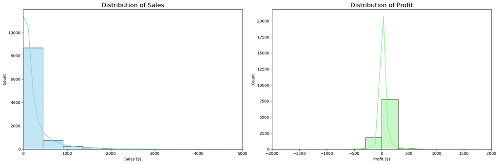

```
--- Descriptive Statistics for Sales and Profit ---
              sales       profit
count   9993.000000  9993.000000
mean     229.852846    28.660971
std      623.276074   234.271476
min        0.444000 -6599.978000
25%       17.280000     1.731000
50%       54.480000     8.671000
75%      209.940000    29.364000
max    22638.480000  8399.976000
```

**Observations:**

- **Heavily Skewed Distributions:** Both `sales` and `profit` are heavily right-skewed. The vast majority of transactions are small-value sales that generate a small profit. The mean is pulled to the right by a small number of very large transactions.
- **Significant Losses:** The `profit` distribution shows a substantial number of transactions result in a loss (values less than 0). The minimum profit is a staggering loss of over $6,500. This is a major red flag that needs further investigation.

**Insight:** The business is a "game of singles," driven by a high volume of low-value transactions. However, there are significant outlier events (both huge wins and huge losses) that heavily influence the overall profit. A key analytical goal will be to identify what causes these extreme outcomes.

### 3.2 Product Category and Sub-Category Analysis

Now that we understand the overall sales and profit landscape, let's identify which product categories and sub-categories are the most significant contributors to the business. We will analyze this from two angles:

1. **Total Contribution:** Which categories generate the most total sales and profit?
2. **Profitability:** Which categories have the best profit margins and distributions?

#### Total Sales and Profit by Category

```
--- Total Sales and Profit by Category ---
          category        sales       profit
2       Technology  836154.0330  145454.9481
1  Office Supplies  719047.0320  122490.8008
0        Furniture  741718.4233   18463.3316
```

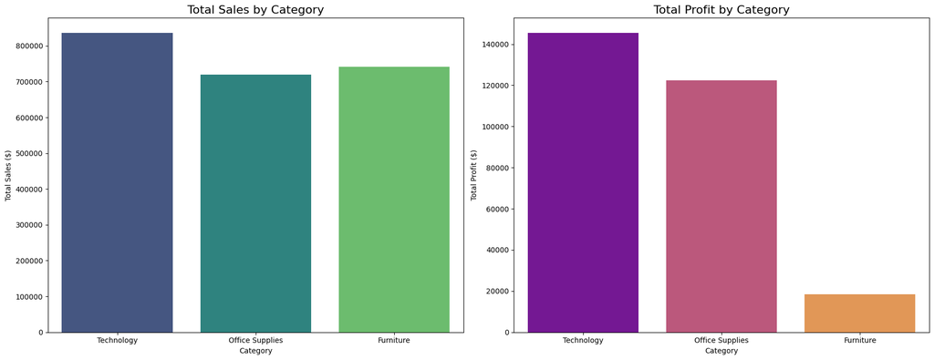

**Observation (Category Level):**

- **Technology** is the clear leader in both sales and profit, generating the most revenue and the highest total profit.
- **Office Supplies** generates a moderate amount of sales and a healthy profit.
- **Furniture** is a major **problem area**. Despite generating the second-highest sales, it produces by far the **lowest total profit**. The profit is barely positive, indicating that this category is either operating on razor-thin margins or is incurring significant losses on some products.

**Insight:** The `Furniture` category requires immediate investigation. Why are high sales not translating into profit? This leads us perfectly into a deeper dive at the sub-category level.

#### Profitability Analysis: A Deep Dive into Sub-Categories

The aggregate data shows that `Furniture` is a problem category. To understand why, we need to analyze the *distribution* of profit for each `sub_category`. A box plot is the perfect tool to see which specific products are driving down the profitability of the entire category.

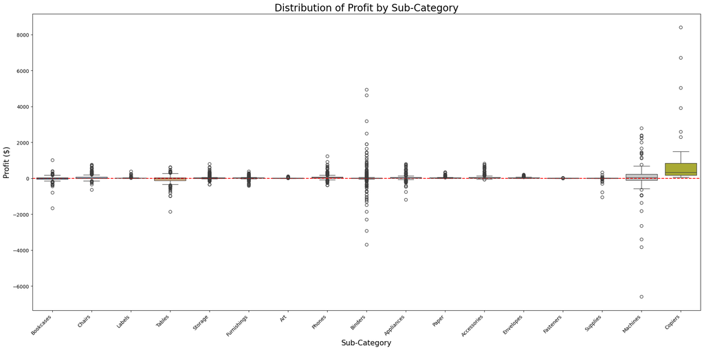

The box plot provides a detailed view of the profit distribution for each sub-category, confirming that `Tables` and `Bookcases` are consistently unprofitable. However, to understand the *total impact* on the business, we need to consider both the average profitability and the total sales volume.

Let's create a summary table that shows the `sum` of sales and profit alongside the `mean` profit for each sub-category. This will help us see how small, consistent losses can add up.

```
--- Detailed Performance by Sub-Category (Sorted by Total Profit) ---
```

|  | category | sub_category | total_sales | total_profit | mean_profit | mean_discount | total_quantity |
| --- | --- | --- | --- | --- | --- | --- | --- |
| 14 | Technology | Copiers | $149,528.03 | $55,617.82 | $817.91 | 16.18% | 234 |
| 16 | Technology | Phones | $330,007.05 | $44,515.73 | $50.07 | 15.46% | 3289 |
| 13 | Technology | Accessories | $167,380.32 | $41,936.64 | $54.11 | 7.85% | 2976 |
| 10 | Office Supplies | Paper | $78,479.21 | $34,053.57 | $24.86 | 7.49% | 5178 |
| 6 | Office Supplies | Binders | $203,412.73 | $30,221.76 | $19.84 | 37.23% | 5974 |
| 1 | Furniture | Chairs | $328,167.73 | $26,602.23 | $43.19 | 17.00% | 2354 |
| 11 | Office Supplies | Storage | $223,843.61 | $21,278.83 | $25.15 | 7.47% | 3158 |
| 4 | Office Supplies | Appliances | $107,532.16 | $18,138.01 | $38.92 | 16.65% | 1729 |
| 2 | Furniture | Furnishings | $91,705.16 | $13,059.14 | $13.65 | 13.83% | 3563 |
| 7 | Office Supplies | Envelopes | $16,476.40 | $6,964.18 | $27.42 | 8.03% | 906 |
| 5 | Office Supplies | Art | $27,118.79 | $6,527.79 | $8.20 | 7.49% | 3000 |
| 9 | Office Supplies | Labels | $12,486.31 | $5,546.25 | $15.24 | 6.87% | 1400 |
| 15 | Technology | Machines | $189,238.63 | $3,384.76 | $29.43 | 30.61% | 440 |
| 8 | Office Supplies | Fasteners | $3,024.28 | $949.52 | $4.38 | 8.20% | 914 |
| 12 | Office Supplies | Supplies | $46,673.54 | $-1,189.10 | $-6.26 | 7.68% | 647 |
| 0 | Furniture | Bookcases | $114,880.00 | $-3,472.56 | $-15.23 | 21.11% | 868 |
| 3 | Furniture | Tables | $206,965.53 | $-17,725.48 | $-55.57 | 26.13% | 1241 |

**Final Insight on Product Performance:**

The detailed summary table provides the definitive answer. The `Furniture` category is unprofitable primarily due to two sub-categories:

- **Tables:** This is the biggest problem. High sales volume combined with a consistently negative average profit (driven by high average discounts) results in a massive total loss for the company.
- **Bookcases:** A similar but smaller-scale issue of unprofitability.

Conversely, the most profitable sub-categories are `Copiers` and `Phones`, which combine high sales with high average profit margins. This analysis pinpoints exactly where the business should focus its efforts: **re-evaluating the pricing and discount strategy for the `Tables` sub-category is a top priority.**

### 3.3 Temporal Analysis: Sales and Profit Over Time

Now that we understand *what* we sell, let's analyze *when* we sell it. By analyzing sales and profit trends over time, we can identify growth patterns, seasonality, and other time-based insights that are crucial for forecasting, inventory management, and marketing campaigns.

Our first step is to aggregate our transactional data into a monthly time series.

```
--- First 5 Months of Aggregated Performance ---
                sales     profit
order_date
2014-01-31  14236.895  2450.1907
2014-02-28   4519.892   862.3084
2014-03-31  55691.009   498.7299
2014-04-30  28013.973  3500.8940
2014-05-31  23648.287  2738.7096
```

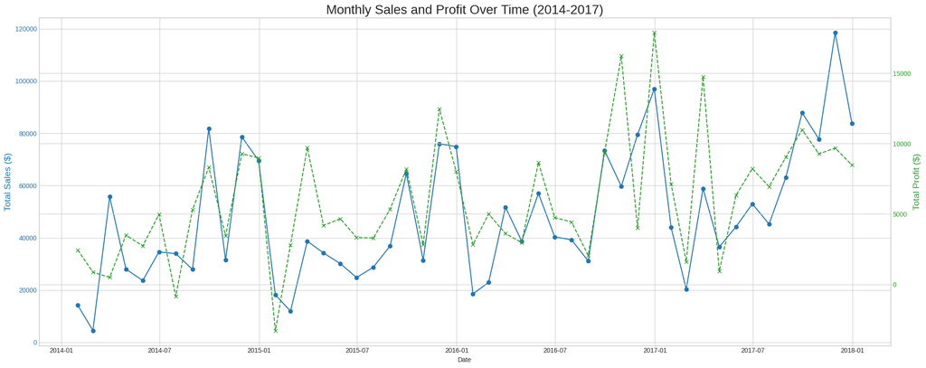

**Observations from the Time Series Plot:**

**Insight and Business Value:**

- **Forecasting:** The clear trend and seasonality mean that future sales are highly predictable. The business can use this for inventory planning, ensuring they are well-stocked for the Q4 rush.
- **Marketing:** Marketing campaigns can be timed to coincide with or boost the natural seasonal peaks. For example, a "Back to Business" sale in September could lead into the Q4 spike.
- **Performance Management:** The company can set realistic, seasonally-adjusted targets. A sales dip in February is normal and not a cause for panic, whereas a dip in November would be a major red flag.

## 3.4 Geographical Analysis: Performance by Location

The final pillar of our EDA is to understand *where* our business thrives and where it struggles. By analyzing sales and profit across different regions, states, and cities, we can identify key markets, uncover regional performance issues, and inform decisions related to marketing, logistics, and expansion.

As you noted, the key business questions this analysis can answer are:

- Which regions are our most profitable strongholds?
- Are there underperforming states that need attention?
- Can we identify specific cities that are either cash cows or major loss centers?
- Where should we focus targeted advertising campaigns or logistical optimizations?

We'll start at the highest level: `Region`.

```
--- Total Sales and Profit by Region ---
    region        sales       profit
3     West  725457.8245  108418.4489
1     East  678499.8680   91534.8388
2    South  391721.9050   46749.4303
0  Central  501239.8908   39706.3625
```

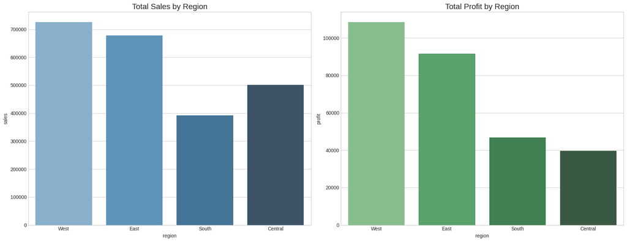

#### State-Level Performance

The regional analysis provides a good overview, but state-level performance is more actionable. Let's identify our top 10 most profitable and bottom 10 least profitable states. This will highlight where our strategy is working and where it's failing.

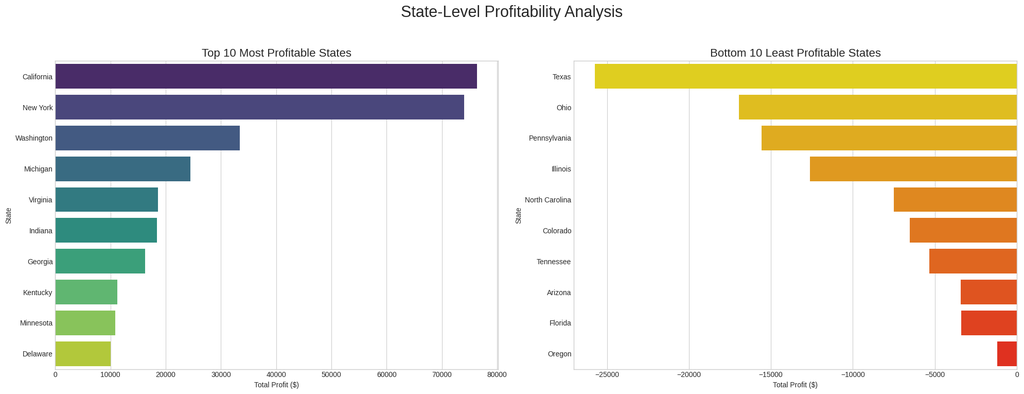

#### City-Level Deep Dive

The state-level analysis reveals several states with significant losses, such as Texas, Ohio, and Pennsylvania. To understand the root cause, we can drill down to the city level to see if specific metropolitan areas are responsible for these losses.

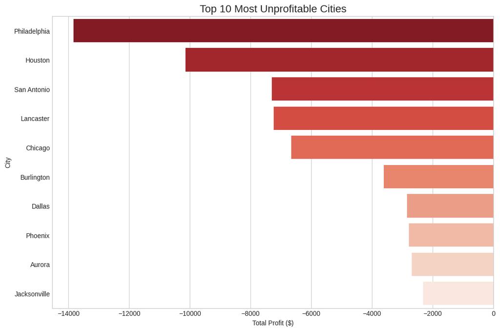

**Geographical Insights:**

- **Key Markets:** California and New York are the undisputed titans, driving a massive portion of both sales and profit. Washington, Michigan, and Virginia are also very strong performers.
- **Problem States:** The analysis clearly pinpoints several states—**Texas, Ohio, Pennsylvania, Illinois, North Carolina, and Florida**—as major sources of unprofitability. These states generate sales but result in an overall loss for the company.
- **Root Cause at City Level:** The city-level analysis shows that the losses in these states are not evenly distributed. They are concentrated in major metropolitan areas like Philadelphia, Houston, San Antonio, Chicago, etc.

**Actionable Recommendations:** The company must conduct an urgent strategic review of its operations in the identified problem states and cities. This could involve re-evaluating local pricing, discount strategies, shipping costs, or competitor presence in these specific markets. Conversely, the successful strategies in California and New York could be studied and potentially replicated in other regions.

## 3.5 Customer-Centric Analysis: The "Who?"

Our analysis has so far focused on products, time, and location. However, a crucial dimension is the customer themselves. Are our profits and losses driven by a wide range of customers, or are there specific "whale" customers (high value) and "problem" customers (high loss) that we should be aware of?

Let's investigate the performance at the individual customer level.

```
--- Top 10 Most Profitable Customers (by Customer ID) ---
    customer_id      segment      sales     profit
741    TC-20980    Corporate  19052.218  8981.3239
621    RB-19360     Consumer  15117.339  6976.0959
669    SC-20095     Consumer  14142.334  5757.4119
327    HL-15040     Consumer  12873.298  5622.4292
6      AB-10105     Consumer  14473.571  5444.8055
730    TA-21385  Home Office  14595.620  4703.7883
160    CM-12385     Consumer   8954.020  3899.8904
424    KD-16495    Corporate   8181.256  3038.6254
48     AR-10540     Consumer   6608.448  2884.6208
234    DR-12940  Home Office   8350.868  2869.0760

==================================================

--- Top 10 Least Profitable (Problem) Customers (by Customer ID) ---
    customer_id      segment      sales     profit
180    CS-12505     Consumer   5690.055 -6626.3895
310    GT-14635    Corporate   9351.212 -4108.6589
459    LF-17185     Consumer   3930.509 -3583.9770
711    SR-20425  Home Office   3233.481 -3333.9144
322    HG-14965    Corporate   3247.642 -2797.9635
555    NC-18415     Consumer   2218.990 -2204.8072
666    SB-20290    Corporate   8057.891 -2082.7451
700    SM-20320  Home Office  25043.050 -1980.7393
165    CP-12340    Corporate   5888.275 -1850.3029
560    NF-18385     Consumer   8322.826 -1695.9714
```

**Insight and Actionable Recommendations:**

This customer-level view is perhaps the most tactically useful analysis we've performed.

1. **VIP Program:** The top profitable `customer_id`s should be immediately flagged in the company's CRM for a VIP program.
2. **Urgent Account Review:** The "problem" `customer_id`s require an immediate account review. For example, a drill-down into customer **'CS-12505'** reveals that the entire **-$6,626 loss** is driven by a single transaction on a high-ticket item (likely a 'Machine') with an extremely high discount.

This moves the problem from a vague "we have unprofitable customers" to a highly specific **"We need to review our discount policy on high-ticket technology items in certain regions, as it's causing catastrophic losses on individual sales."** This is a direct, data-driven insight for the sales and pricing strategy teams.

```
--- All Transactions for Customer CS-12505 (Sorted by Profit) ---
```

|  | order_id | order_date | ship_date | ship_mode | customer_id | segment | city | state | postal_code | region | product_id | category | sub_category | product_name | sales | quantity | discount | profit | shipping_time |
| --- | --- | --- | --- | --- | --- | --- | --- | --- | --- | --- | --- | --- | --- | --- | --- | --- | --- | --- | --- |
| 7771 | CA-2016-108196 | 2016-11-25 | 2016-12-02 | Standard Class | CS-12505 | Consumer | Lancaster | Ohio | 43130 | East | TEC-MA-10000418 | Technology | Machines | Cubify CubeX 3D Printer Double Head Print | 4499.985 | 5 | 0.7 | -6599.9780 | 7 days |
| 7770 | CA-2016-108196 | 2016-11-25 | 2016-12-02 | Standard Class | CS-12505 | Consumer | Lancaster | Ohio | 43130 | East | OFF-BI-10000545 | Office Supplies | Binders | GBC Ibimaster 500 Manual ProClick Binding System | 456.588 | 2 | 0.7 | -304.3920 | 7 days |
| 2803 | CA-2015-159380 | 2015-05-12 | 2015-05-16 | Standard Class | CS-12505 | Consumer | San Francisco | California | 94122 | West | OFF-PA-10003893 | Office Supplies | Paper | Xerox 1962 | 12.840 | 3 | 0.0 | 5.7780 | 4 days |
| 1477 | CA-2016-121958 | 2016-11-13 | 2016-11-17 | Standard Class | CS-12505 | Consumer | Thomasville | North Carolina | 27360 | South | OFF-SU-10000381 | Office Supplies | Supplies | Acme Forged Steel Scissors with Black Enamel H... | 52.136 | 7 | 0.2 | 5.8653 | 4 days |
| 9658 | CA-2014-100860 | 2014-03-26 | 2014-03-30 | Second Class | CS-12505 | Consumer | Pomona | California | 91767 | West | OFF-LA-10001982 | Office Supplies | Labels | Smead Alpha-Z Color-Coded Name Labels First Le... | 18.750 | 5 | 0.0 | 9.0000 | 4 days |
| 2804 | CA-2015-159380 | 2015-05-12 | 2015-05-16 | Standard Class | CS-12505 | Consumer | San Francisco | California | 94122 | West | OFF-PA-10004239 | Office Supplies | Paper | Xerox 1953 | 25.680 | 6 | 0.0 | 11.5560 | 4 days |
| 7772 | CA-2016-108196 | 2016-11-25 | 2016-12-02 | Standard Class | CS-12505 | Consumer | Lancaster | Ohio | 43130 | East | TEC-AC-10000926 | Technology | Accessories | NETGEAR RangeMax WNR1000 Wireless Router | 59.976 | 3 | 0.2 | 11.9952 | 7 days |
| 6821 | US-2017-115609 | 2017-11-02 | 2017-11-07 | Standard Class | CS-12505 | Consumer | Los Angeles | California | 90036 | West | OFF-AP-10003040 | Office Supplies | Appliances | Fellowes 8 Outlet Superior Workstation Surge P... | 168.100 | 5 | 0.0 | 43.7060 | 5 days |
| 1507 | CA-2016-134208 | 2016-09-17 | 2016-09-23 | Standard Class | CS-12505 | Consumer | Columbus | Georgia | 31907 | South | TEC-MA-10004458 | Technology | Machines | Lexmark X 9575 Professional All-in-One Color P... | 396.000 | 4 | 0.0 | 190.0800 | 6 days |

#### Observation

The "Cubify CubeX 3D Printer" is the Culprit: The single line item for this 3D printer resulted in a staggering loss of -$6,599.98. This one item is responsible for virtually the entire loss associated with this customer.

The Reason is the Discount: The discount applied to that printer was 70% (0.7). This is an astronomically high discount for a high-ticket technology item. The business sold five units of a ~3000 printer for about 900 each, leading to a massive loss. The same 70% discount was applied to the Binders in the same order, also causing a significant loss.

The Geographic Connection: This disastrous order was shipped to Lancaster, Ohio. This connects directly to our earlier geographical analysis, where we saw that Ohio was one of the most unprofitable states. This transaction is a major contributor to Ohio's poor performance.

Normal Customer Behavior Otherwise: Outside of this one order, the customer's other purchases were normal, profitable transactions for standard office supplies in California and Georgia, with reasonable or zero discounts. This shows that the problem isn't the customer per se, but the specific conditions of that one high-loss order.

**Final Insight from Customer Drill-Down:**

The customer-level analysis provides the most specific and actionable insight of this entire EDA. By drilling down into the single most unprofitable customer, `CS-12505`, we discovered that the **-$6,626 loss was not due to a pattern of behavior, but to a single order (`CA-2016-108196`)**.

Within this order, a **70% discount** was applied to a high-ticket technology item (a 3D printer), resulting in a loss of over $6,500 on that item alone. This transaction occurred in **Ohio**, one of the most unprofitable states identified earlier.

**This is the root cause.** The company's overall unprofitability is not just a general trend; it is heavily impacted by specific instances of an aggressive or perhaps flawed **discounting strategy on high-value items in certain geographical regions.**

**Actionable Recommendation:** The #1 recommendation from this analysis is for management to conduct an **urgent review of the discount authorization policy**.

- Who is authorized to give a 70% discount?
- What is the maximum allowable discount for products in the `Technology` category, especially in states that are already unprofitable?
- Implementing stricter controls on high-value discounts could prevent these catastrophic losses and dramatically improve the company's bottom line.

## 4. Executive Summary & Strategic Recommendations

This comprehensive Exploratory Data Analysis of the Superstore dataset has yielded critical insights into the company's operational performance. By analyzing sales, profit, product, temporal, geographical, and customer data, we have identified key areas of strength to leverage and significant problems to address.

### Key Findings at a Glance:

- **Overall Health:** The business is on a clear growth trajectory, with sales increasing year-over-year. However, profitability is highly volatile and significantly hampered by specific, identifiable issues.
- **Product Performance:** `Technology` is the most profitable category, driven by high-margin products like `Copiers` and `Phones`. The `Furniture` category is a major problem area, generating high sales but minimal profit due to massive losses in the `Tables` sub-category.
- **Temporal Patterns:** The business is seasonal, with a significant sales and profit spike in Q4 of each year. This provides a predictable pattern for inventory and marketing planning.
- **Geographical Landscape:** Performance is highly concentrated. California and New York are powerhouse states driving the majority of profit. Conversely, several large states, including Texas, Pennsylvania, and Ohio, are significant loss centers.

### The Root Cause of Unprofitability:

The single most significant issue discovered is the company's **discounting strategy on high-ticket items in unprofitable regions.** Our drill-down analysis revealed that a single customer order for five 3D printers in Ohio, sold at a 70% discount, resulted in a loss of over $6,500. This one transaction highlights a systemic problem where aggressive discounts are destroying profit margins.

### Top-Priority Strategic Recommendations:

1. **Urgent Discount Policy Review:** Immediately implement stricter controls and approval processes for discounts exceeding a certain threshold (e.g., 25-30%), especially for high-cost technology items and within states that are already unprofitable.
2. **Re-evaluate the "Tables" Sub-Category:** The `Tables` product line is a consistent loss leader. A full review of its pricing, sourcing costs, and discount strategy is required. The company should consider discontinuing unprofitable models if margins cannot be improved.
3. **Focus and Replicate Success:** Double down on the successful strategies used in California and New York. Analyze the product mix and sales tactics in these regions to create a playbook that can be applied to mid-tier states.
4. **Implement a Customer VIP Program:** Identify and assign account managers to the top 10-20 most profitable customers to ensure their retention, as they represent a disproportionately large share of the company's profit.

This data-driven analysis provides a clear roadmap for improving profitability and operational efficiency. The next step would be to develop targeted action plans based on these strategic recommendations.

[output not shown]